# DSSS2022 Machine Learning in R: Task List 07

Goran S. Milovanovic, DataKolektiv

# Cross-Validation and Regularization in CART (Classification and Regression Trees)

In this exercise we will perform a complete cross-validation (CV) of a Decision Tree model.

```r
library(tidyverse)
library(rpart)
data_dir <- paste0(getwd(), "/_data/")
```

### Step 01: The Dataset

We will use the **Kaggle** Bank Customer Churn Prediction competition dataset in this exercise. You will need to download the `Churn_Modelling.csv` data file into your `_data` directory. The task is to predict the `Exited` variable, making this pretty much a churn prediction problem.

```r
data_set <- read.csv(paste0(data_dir, "Churn_Modelling.csv"),
                     header = TRUE,
                     check.names = FALSE,
                     stringsAsFactors = FALSE)
head(data_set)
```

|  | RowNumber | CustomerId | Surname | CreditScore | Geography | Gender | Age | Tenure | Balance | NumOfProducts | HasCrCard | IsActiveMember | EstimatedSalary | Exited |
| --- | --- | --- | --- | --- | --- | --- | --- | --- | --- | --- | --- | --- | --- | --- |
| 1 | 1 | 15634602 | Hargrave | 619 | France | Female | 42 | 2 | 0.00 | 1 | 1 | 1 | 101348.88 | 1 |
| 2 | 2 | 15647311 | Hill | 608 | Spain | Female | 41 | 1 | 83807.86 | 1 | 0 | 1 | 112542.58 | 0 |
| 3 | 3 | 15619304 | Onio | 502 | France | Female | 42 | 8 | 159660.80 | 3 | 1 | 0 | 113931.57 | 1 |
| 4 | 4 | 15701354 | Boni | 699 | France | Female | 39 | 1 | 0.00 | 2 | 0 | 0 | 93826.63 | 0 |
| 5 | 5 | 15737888 | Mitchell | 850 | Spain | Female | 43 | 2 | 125510.82 | 1 | 1 | 1 | 79084.10 | 0 |
| 6 | 6 | 15574012 | Chu | 645 | Spain | Male | 44 | 8 | 113755.78 | 2 | 1 | 0 | 149756.71 | 1 |

Let’s describe the data at hand:

```r
glimpse(data_set)
```

```
Rows: 10,000
Columns: 14
$ RowNumber       <int> 1, 2, 3, 4, 5, 6, 7, 8, 9, 10, 11, 12, 13, 14, 15, 16, 17, 18, 19,…
$ CustomerId      <int> 15634602, 15647311, 15619304, 15701354, 15737888, 15574012, 155925…
$ Surname         <chr> "Hargrave", "Hill", "Onio", "Boni", "Mitchell", "Chu", "Bartlett",…
$ CreditScore     <int> 619, 608, 502, 699, 850, 645, 822, 376, 501, 684, 528, 497, 476, 5…
$ Geography       <chr> "France", "Spain", "France", "France", "Spain", "Spain", "France",…
$ Gender          <chr> "Female", "Female", "Female", "Female", "Female", "Male", "Male", …
$ Age             <int> 42, 41, 42, 39, 43, 44, 50, 29, 44, 27, 31, 24, 34, 25, 35, 45, 58…
$ Tenure          <int> 2, 1, 8, 1, 2, 8, 7, 4, 4, 2, 6, 3, 10, 5, 7, 3, 1, 9, 6, 6, 8, 8,…
$ Balance         <dbl> 0.00, 83807.86, 159660.80, 0.00, 125510.82, 113755.78, 0.00, 11504…
$ NumOfProducts   <int> 1, 1, 3, 2, 1, 2, 2, 4, 2, 1, 2, 2, 2, 2, 2, 2, 1, 2, 1, 2, 2, 2, …
$ HasCrCard       <int> 1, 0, 1, 0, 1, 1, 1, 1, 0, 1, 0, 1, 1, 0, 1, 0, 1, 1, 0, 1, 1, 1, …
$ IsActiveMember  <int> 1, 1, 0, 0, 1, 0, 1, 0, 1, 1, 0, 0, 0, 0, 1, 1, 0, 1, 0, 1, 1, 0, …
$ EstimatedSalary <dbl> 101348.88, 112542.58, 113931.57, 93826.63, 79084.10, 149756.71, 10…
$ Exited          <int> 1, 0, 1, 0, 0, 1, 0, 1, 0, 0, 0, 0, 0, 0, 0, 0, 1, 0, 0, 0, 0, 0, …
```

`RowNumber`, `Surname`, and `CustomerId` cannot be used in the prediction of `Exited`, of course.

```r
data_set <- data_set %>%
  select(-any_of(c("RowNumber", "Surname", "CustomerId")))
```

### Task 01

- Grow the whole tree first, then prune the model at the optimal value of the Complexity Parameter (cp)
- Use the `predict()` function to predict `Exit` class probabilities and turn them into class values (`0` or `1`) using a Decision Threshold of `.5`
- Compute the accuracy, True Positive (Hit) Rate, and False Positive (False Alarm) Rate for this model

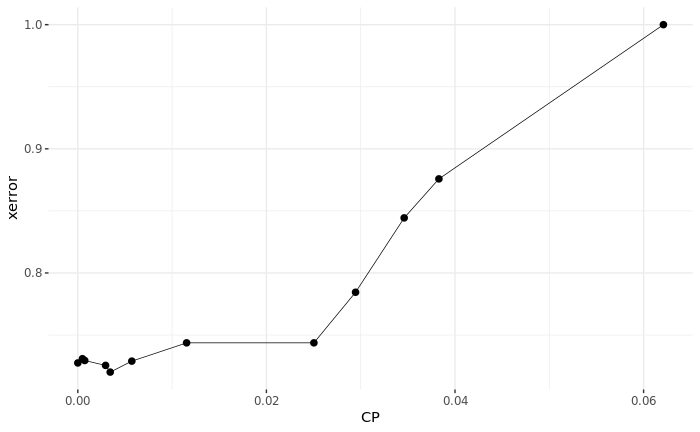

```r
# - fit a Decision Tree model
rpart_model <- rpart(Exited ~ .,
                     data = data_set,
                     control =  list(cp = 0,
                                     minsplit = 10,
                                     minbucket = 50,
                                     maxdepth = 7),
                     method = "class"
)

# - inspect the CP vs xerror plot:
cp_frame <- as.data.frame(rpart_model$cptable)
ggplot(data = cp_frame,
       aes(x = CP, y = xerror)) +
  geom_path(group = 1, size = .25) +
  geom_point(size = 2) +
  theme_bw() +
  theme(panel.border = element_blank())
```

Let’s find the minimum `xerror` and pick `CP` accordingly:

```r
optimal_cp <- cp_frame$CP[which.min(cp_frame$xerror)]
print(optimal_cp)
```

```
[1] 0.003436426
```

Re-train the model with `optimal_cp`:

```r
rpart_model <- rpart(Exited ~ .,
                     data = data_set,
                     control =  list(cp = optimal_cp,
                                     minsplit = 10,
                                     minbucket = 50,
                                     maxdepth = 7),
                     method = "class"
)
```

Use `predict()` to predict the probabilities of the `Exited` classes:

```r
predictions <- predict(rpart_model,
                       newdata = data_set,
                       type = "prob")
head(predictions)
```

```
          0         1
1 0.8973510 0.1026490
2 0.8973510 0.1026490
3 0.2562500 0.7437500
4 0.8973510 0.1026490
5 0.7351974 0.2648026
6 0.8137255 0.1862745
```

Use a Decision Threshold of `.5` to turn predicted class probabilities into classes:

```r
predictions <- ifelse(predictions[, 1] > predictions[, 2],
                      0,
                      1)
table(predictions)
```

```
predictions
   0    1
8835 1165
```

Elementary ROC analysis:

```r
accuracy <- sum(predictions == data_set$Exited)/length(data_set$Exited)
print(accuracy)
```

```
[1] 0.8628
```

```r
tpr <- sum(predictions == 1 & data_set$Exited == 1)/sum(data_set$Exited == 1)
print(tpr)
```

```
[1] 0.44919
```

```r
fpr <- sum(predictions == 1 & data_set$Exited == 0)/sum(data_set$Exited == 0)
print(fpr)
```

```
[1] 0.0313952
```

Let’s see if we can make this model better by varying the Decision Threshold

```r
predictions <- predict(rpart_model,
                       newdata = data_set,
                       type = "prob")
dec_thresh <- seq(.01, .99, by = .01)
roc_frame <- lapply(dec_thresh, function(x) {
  preds <- ifelse(predictions[, 2] >= x, 1, 0)
  accuracy <- sum(preds == data_set$Exited)/length(data_set$Exited)
  tpr <- sum(preds == 1 & data_set$Exited == 1)/sum(data_set$Exited == 1)
  fpr <- sum(preds == 1 & data_set$Exited == 0)/sum(data_set$Exited == 0)
  return(
    data.frame(
      acc = accuracy,
      tpr = tpr,
      fpr = fpr,
      dt = x
    )
  )
})
roc_frame <- Reduce(rbind, roc_frame)
print(roc_frame)
```

| acc | tpr | fpr | dt |
| --- | --- | --- | --- |
| 0.2037 | 1.00000000 | 1.0000000000 | 0.01 |
| 0.2037 | 1.00000000 | 1.0000000000 | 0.02 |
| 0.2037 | 1.00000000 | 1.0000000000 | 0.03 |
| 0.2037 | 1.00000000 | 1.0000000000 | 0.04 |
| 0.2037 | 1.00000000 | 1.0000000000 | 0.05 |
| 0.2037 | 1.00000000 | 1.0000000000 | 0.06 |
| 0.2037 | 1.00000000 | 1.0000000000 | 0.07 |
| 0.2037 | 1.00000000 | 1.0000000000 | 0.08 |
| 0.2037 | 1.00000000 | 1.0000000000 | 0.09 |
| 0.2037 | 1.00000000 | 1.0000000000 | 0.10 |

[output cut: 89 more lines]

Plot the ROC for this model:

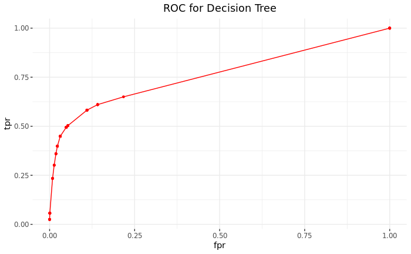

```r
ggplot(data = roc_frame,
       aes(x = fpr,
           y = tpr)) +
  geom_path(group = 1, color = "red", size = .5) +
  geom_point(size = 1, color = "red") +
  ggtitle("ROC for Decision Tree") +
  theme_bw() +
  theme(panel.border = element_blank()) +
  theme(plot.title = element_text(hjust = .5))
```

**Ok, now we have all the elements in place.**